# Máster Universitario en Ciencia de Datos

# Visualización de datos: PEC2

Autor: Gabriela Alejandra Perez

Fecha de entrega: 06 de Noviembre 2025

# 1 Técnica de visualización específica/infrecuente: Sparkline

### 1.1.1 Descripción del Dataset Utilizado

Para esta visualización práctica, he seleccionado datos del **mercado de valores estadounidense**, específicamente las **10 principales empresas tecnológicas** por capitalización de mercado. Los datos provienen de **Yahoo Finance** y abarcan un período de **12 meses** (noviembre 2024 - noviembre 2025).

**Características del dataset:**

- **Fuente:** Yahoo Finance API
- **Período:** 365 días (datos diarios)
- **Variable:** Precio de cierre ajustado en dólares estadounidenses
- **Empresas incluidas:** AAPL (Apple), MSFT (Microsoft), GOOGL (Alphabet/Google), AMZN (Amazon), TSLA (Tesla), META (Meta/Facebook), NVDA (NVIDIA), NFLX (Netflix), ADBE (Adobe), CRM (Salesforce)

| Empresa | Precio Actual | Cambio Anual | Mínimo | Máximo | Tendencia (12 meses) |
| --- | --- | --- | --- | --- | --- |
| AAPL | $270.14 | +21.29% | $172.42 | $271.4 |  |
| MSFT | $507.16 | +20.7% | $354.56 | $542.07 |  |
| GOOGL | $284.31 | +61.07% | $144.7 | $284.31 |  |
| AMZN | $250.2 | +20.82% | $167.32 | $254 |  |
| TSLA | $462.07 | +60.15% | $221.86 | $479.86 |  |
| META | $635.95 | +11.17% | $484.66 | $790 |  |
| NVDA | $195.21 | +34.06% | $94.31 | $207.04 |  |
| NFLX | $1098.46 | +40.79% | $780.21 | $1339.13 |  |
| ADBE | $335.53 | -33.54% | $329.23 | $552.96 |  |
| CRM | $252.68 | -17.67% | $231.66 | $367.87 |  |

[interactive chart not shown]

## 1.2 Otras visualizaciones: SPARKLINE DE BARRAS - Volumen Mensual

Los sparklines de barras representan valores discretos mediante columnas verticales. Son ideales para mostrar:

- Volumen de transacciones por período
- Conteo de eventos o actividades
- Métricas que varían significativamente entre períodos

**Ventaja:** Facilitan la comparación de magnitudes relativas entre períodos.

Procesando volumen de: AAPL Procesando volumen de: TSLA Procesando volumen de: GME

| Empresa | Volumen Promedio (M) | Volumen Máximo (M) | Volumen Mensual (12 meses) |
| --- | --- | --- | --- |
| AAPL | 1071.9M | 1607.3M |  |
| TSLA | 1943.4M | 2958M |  |
| GME | 207.8M | 455.1M |  |

[interactive chart not shown]

## 1.3 Otras visualizaciones: SPARKLINE WIN/LOSS - Rendimiento Mensual

Los sparklines de ganancia/pérdida (también llamados “tristate”) representan valores positivos, negativos y neutros mediante barras de colores. Son útiles para:

- Identificar rachas de éxito o fracaso
- Visualizar consistencia de resultados
- Detectar patrones de alternancia

**Ventaja:** Resalta inmediatamente períodos favorables vs. desfavorables sin necesidad de leer números.

Procesando rendimiento mensual de: NVDA Procesando rendimiento mensual de: ADBE Procesando rendimiento mensual de: CRM

| Empresa | Meses ↑ | Meses ↓ | Rendimiento Mensual (12 meses) |
| --- | --- | --- | --- |
| NVDA | 7 meses | 5 meses |  |
| ADBE | 2 meses | 10 meses |  |
| CRM | 5 meses | 7 meses |  |

[interactive chart not shown]

# 2 Técnica de visualización avanzada: Diagrama de Red

## 2.1 Visualización práctica

### 2.1.1 Descripción del Dataset

Para esta visualización he utilizado el dataset **USA Airport Flight Routes** de Kaggle, que contiene información detallada sobre rutas aéreas comerciales entre aeropuertos de Estados Unidos, incluyendo número de pasajeros, vuelos y distancias.

**Fuente:** Kaggle - USA Airport Dataset  
**URL:** https://www.kaggle.com/datasets/flashgordon/usa-airport-dataset  
**Período:** 1990-2009  
**Registros:** Más de 3 millones de vuelos

```r
# Instalar paquetes necesarios para el diagrama de red

library(readr)
library(dplyr)
library(dplyr)
library(visNetwork)
library(igraph)
library(knitr)
library(kableExtra)
library(leaflet)
library(geosphere)

# Leer el archivo (ajusta el nombre si es diferente)
datos_vuelos <- read_csv("Airports2.csv", show_col_types = FALSE)

# Ver estructura
cat("Total de registros de vuelos:", nrow(datos_vuelos), "\n")
```

```
## Total de registros de vuelos: 3606803
```

```r
cat("Columnas disponibles:", paste(names(datos_vuelos), collapse = ", "), "\n")
```

```
## Columnas disponibles: Origin_airport, Destination_airport, Origin_city, Destination_city, Passengers, Seats, Flights, Distance, Fly_date, Origin_population, Destination_population, Org_airport_lat, Org_airport_long, Dest_airport_lat, Dest_airport_long
```

```r
library(dplyr)
library(leaflet)
library(geosphere)
library(readr)
# ============================================
# 1. EXTRAER AEROPUERTOS ÚNICOS
# ============================================

# Obtener aeropuertos de origen
aeropuertos_origen <- datos_vuelos %>%
  select(
    codigo = Origin_airport,
    ciudad = Origin_city,
    lat = Org_airport_lat,
    lon = Org_airport_long,
    poblacion = Origin_population
  ) %>%
  distinct()

# Obtener aeropuertos de destino
aeropuertos_destino <- datos_vuelos %>%
  select(
    codigo = Destination_airport,
    ciudad = Destination_city,
    lat = Dest_airport_lat,
    lon = Dest_airport_long,
    poblacion = Destination_population
  ) %>%
  distinct()

# Combinar y eliminar duplicados
aeropuertos_todos <- bind_rows(aeropuertos_origen, aeropuertos_destino) %>%
  group_by(codigo) %>%
  summarise(
    ciudad = first(na.omit(ciudad)),
    lat = first(na.omit(lat)),
    lon = first(na.omit(lon)),
    poblacion = first(na.omit(poblacion)),
    .groups = "drop"
  ) %>%
  filter(!is.na(lat), !is.na(lon)) # Eliminar aeropuertos sin coordenadas

cat("\nTotal de aeropuertos únicos con coordenadas:", nrow(aeropuertos_todos), "\n")
```

```
##
## Total de aeropuertos únicos con coordenadas: 484
```

```r
# ============================================
# 2. AGREGAR RUTAS Y FILTRAR
# ============================================

# Agregar datos por ruta (sumar pasajeros, vuelos)
rutas_agregadas <- datos_vuelos %>%
  filter(!is.na(Org_airport_lat), !is.na(Dest_airport_lat)) %>%
  group_by(Origin_airport, Destination_airport) %>%
  summarise(
    total_pasajeros = sum(Passengers, na.rm = TRUE),
    total_vuelos = sum(Flights, na.rm = TRUE),
    distancia = first(Distance),
    .groups = "drop"
  ) %>%
  arrange(desc(total_pasajeros))

# Seleccionar solo los TOP 15 aeropuertos por tráfico
top_aeropuertos <- rutas_agregadas %>%
  group_by(Origin_airport) %>%
  summarise(trafico = sum(total_pasajeros), .groups = "drop") %>%
  arrange(desc(trafico)) %>%
  head(15) %>%
  pull(Origin_airport)

cat("Top 15 aeropuertos por tráfico:", paste(top_aeropuertos, collapse = ", "), "\n")
```

```
## Top 15 aeropuertos por tráfico: ATL, ORD, DFW, LAX, PHX, LAS, DTW, MSP, SFO, IAH, MCO, SEA, EWR, STL, CLT
```

```r
# Filtrar aeropuertos
aeropuertos_viz <- aeropuertos_todos %>%
  filter(codigo %in% top_aeropuertos)

# Filtrar las 50 rutas más transitadas
rutas_viz <- rutas_agregadas %>%
  filter(
    Origin_airport %in% top_aeropuertos,
    Destination_airport %in% top_aeropuertos

  ) %>%
  arrange(desc(total_pasajeros)) %>%
  head(50)

cat("\nAeropuertos para visualización:", nrow(aeropuertos_viz), "\n")
```

```
##
## Aeropuertos para visualización: 15
```

```r
cat("Rutas para visualización:", nrow(rutas_viz), "\n")
```

```
## Rutas para visualización: 50
```

[interactive chart not shown]

## 2.2 Otras visualizaciones: Con mapa

[interactive chart not shown]

# 3 Técnica de visualización básica: Cartograma

### 3.0.1 Descripción del Dataset

Para esta visualización, crearemos un cartograma contiguo de los Estados Unidos, donde el área de cada estado será distorsionada para ser proporcional a su población.

Uniremos estos dos datasets por el nombre del estado y luego usaremos el paquete cartogram para generar la geometría distorsionada.

```r
# Cargar librerías necesarias
library(sf)           # Para manejar datos geoespaciales (simple features)
library(tigris)       # Para descargar las geometrías de los estados
library(cartogram)    # El paquete que crea los cartogramas
library(ggplot2)      # Para visualizar el resultado
library(dplyr)        # Para manipulación de datos
library(stringr)      # Para limpieza de texto

# ============================================
# 1. OBTENER Y PREPARAR DATOS
# ============================================
datos_poblacion <- as.data.frame(state.x77) %>%
  tibble::rownames_to_column("NAME") %>%
  select(NAME, Population)

# Obtener los datos geoespaciales
us_states <- tigris::states(cb = TRUE, resolution = "20m") %>%
  filter(!STUSPS %in% c("AK", "HI", "PR", "VI", "GU", "AS", "MP"))
```

[output not shown]

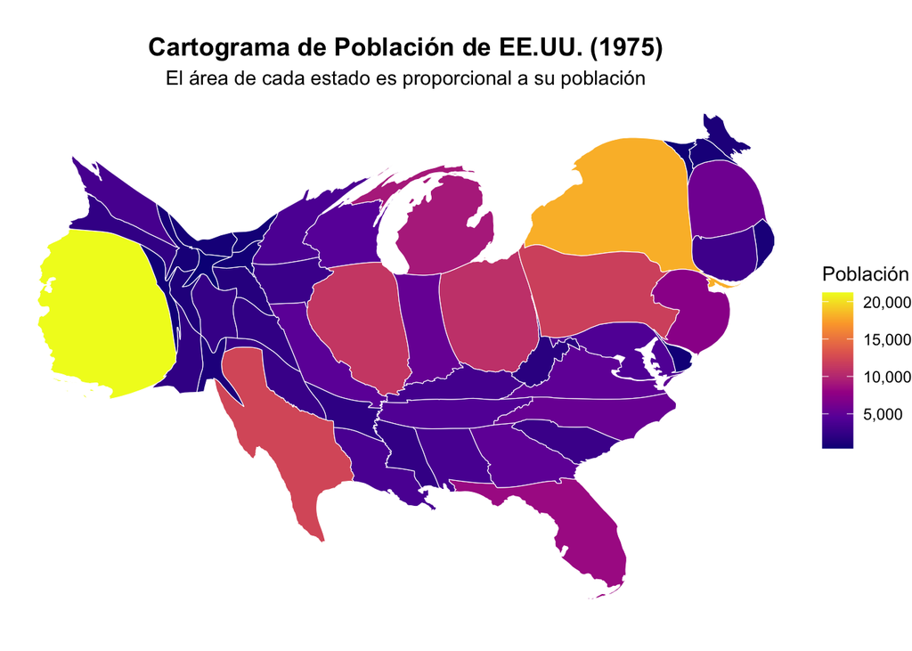

```r
# ============================================
# 2. UNIR DATOS
# ============================================
states_con_poblacion <- us_states %>%
  left_join(datos_poblacion, by = "NAME") %>%
  filter(!is.na(Population)) %>%
  st_transform(5070)

# ============================================
# 3. CONSTRUIR EL CARTOGRAMA
# ============================================
# Usar el namespace explícito para evitar conflictos
carto_us_poblacion <- cartogram::cartogram_cont(
  states_con_poblacion,
  "Population",
  itermax = 10
)

# ============================================
# 4. VISUALIZAR
# ============================================
ggplot(carto_us_poblacion) +
  geom_sf(aes(fill = Population), color = "white", linewidth = 0.2) +
  scale_fill_viridis_c(
    labels = scales::comma,
    option = "plasma"
  ) +
  labs(
    title = "Cartograma de Población de EE.UU. (1975)",
    subtitle = "El área de cada estado es proporcional a su población",
    fill = "Población"
  ) +
  theme_void() +
  theme(
    plot.title = element_text(hjust = 0.5, face = "bold", size = 14),
    plot.subtitle = element_text(hjust = 0.5, size = 11)
  )
```

## 3.1 Conclusiones sobre Cartogramas

Los cartogramas son una herramienta de visualización fundamental para **corregir la percepción geoespacial** y revelar la verdadera magnitud de una variable. Son la técnica superior cuando el objetivo no es mostrar dónde ocurre algo en un sentido geográfico estricto, sino cuál es el peso real de esa variable (como población, riqueza o poder electoral).

Su efectividad se maximiza cuando:

1. Se trabaja con **datos de totales absolutos** (ej. población total, PIB total, número de votos).
2. El objetivo es **desafiar el sesgo visual** que introducen los mapas tradicionales, donde áreas geográficas extensas pero con valores bajos (ej. estados rurales, países desérticos) dominan la visualización.
3. Se busca una **comunicación impactante** que muestre la escala “humana” o “económica” de un fenómeno.

La principal contrapartida del cartograma es el **sacrificio de la precisión geométrica**. Al distorsionar el área, las formas familiares de los países o estados pueden volverse irreconocibles, lo que requiere un esfuerzo cognitivo inicial por parte del espectador.

Sin embargo, este “costo” es precisamente su fortaleza: el cartograma obliga al usuario a dejar de ver la geografía (la tierra) y a empezar a ver los datos (las personas, el dinero, los votos), proporcionando una perspectiva más justa y precisa de la distribución del fenómeno estudiado.